# Building a Decision Tree Workflow

1. Introduction
2. Step 1: Imports
3. Step 2: Data Exploration
4. Step 3: Model Building
5. Step 4: Results and Evaluation
6. Considerations

[figure not shown]

# Introduction

> - For this Project, I work as a consultant for an airline. The airline is interested in predicting whether a future customer would be satisfied with their services given previous customer feedback about their flight experience. The airline would like me to construct and evaluate a model that can accomplish this goal. Specifically, they are interested in knowing which features are most important to customer satisfaction.

**The Purpose**: To demonstrate an active and working knowledge of building decision trees that are used across a wide array of industries.

**The Goal**: To utilize a decision tree model to predict whether or not a customer will be satisfied with their flight experience.

### Within this project I will demonstrate the following skills:

- Importing packages and loading data
- Exploring the data and completing the cleaning process
- Building a decision tree model
- Tuning hyperparameters using `GridSearchCV`
- Evaluating a decision tree model using a confusion matrix and various other plots

# Step 1: Imports

```python
# Standard operational package imports
import numpy as np
import pandas as pd

# Important imports for modeling and evaluation
from sklearn.model_selection import train_test_split
from sklearn.model_selection import GridSearchCV
from sklearn.tree import DecisionTreeClassifier
from sklearn.tree import plot_tree
import sklearn.metrics as metrics

# Visualization package imports
import matplotlib.pyplot as plt
import seaborn as sns
```

### Loading the dataset

```python
# Importing the dataset
df_original = pd.read_csv("Invistico_Airline.csv")
```

# Step 2: Data Exploration

### Outputting the first 10 rows of the dataset

```python
df_original.head(10)
```

|  | satisfaction | Customer Type | Age | Type of Travel | Class | Flight Distance | Seat comfort | Departure/Arrival time convenient | Food and drink | Gate location | ... | Online support | Ease of Online booking | On-board service | Leg room service | Baggage handling | Checkin service | Cleanliness | Online boarding | Departure Delay in Minutes | Arrival Delay in Minutes |
| --- | --- | --- | --- | --- | --- | --- | --- | --- | --- | --- | --- | --- | --- | --- | --- | --- | --- | --- | --- | --- | --- |
| 0 | satisfied | Loyal Customer | 65 | Personal Travel | Eco | 265 | 0 | 0 | 0 | 2 | ... | 2 | 3 | 3 | 0 | 3 | 5 | 3 | 2 | 0 | 0.0 |
| 1 | satisfied | Loyal Customer | 47 | Personal Travel | Business | 2464 | 0 | 0 | 0 | 3 | ... | 2 | 3 | 4 | 4 | 4 | 2 | 3 | 2 | 310 | 305.0 |
| 2 | satisfied | Loyal Customer | 15 | Personal Travel | Eco | 2138 | 0 | 0 | 0 | 3 | ... | 2 | 2 | 3 | 3 | 4 | 4 | 4 | 2 | 0 | 0.0 |
| 3 | satisfied | Loyal Customer | 60 | Personal Travel | Eco | 623 | 0 | 0 | 0 | 3 | ... | 3 | 1 | 1 | 0 | 1 | 4 | 1 | 3 | 0 | 0.0 |
| 4 | satisfied | Loyal Customer | 70 | Personal Travel | Eco | 354 | 0 | 0 | 0 | 3 | ... | 4 | 2 | 2 | 0 | 2 | 4 | 2 | 5 | 0 | 0.0 |
| 5 | satisfied | Loyal Customer | 30 | Personal Travel | Eco | 1894 | 0 | 0 | 0 | 3 | ... | 2 | 2 | 5 | 4 | 5 | 5 | 4 | 2 | 0 | 0.0 |
| 6 | satisfied | Loyal Customer | 66 | Personal Travel | Eco | 227 | 0 | 0 | 0 | 3 | ... | 5 | 5 | 5 | 0 | 5 | 5 | 5 | 3 | 17 | 15.0 |
| 7 | satisfied | Loyal Customer | 10 | Personal Travel | Eco | 1812 | 0 | 0 | 0 | 3 | ... | 2 | 2 | 3 | 3 | 4 | 5 | 4 | 2 | 0 | 0.0 |
| 8 | satisfied | Loyal Customer | 56 | Personal Travel | Business | 73 | 0 | 0 | 0 | 3 | ... | 5 | 4 | 4 | 0 | 1 | 5 | 4 | 4 | 0 | 0.0 |
| 9 | satisfied | Loyal Customer | 22 | Personal Travel | Eco | 1556 | 0 | 0 | 0 | 3 | ... | 2 | 2 | 2 | 4 | 5 | 3 | 4 | 2 | 30 | 26.0 |

10 rows × 22 columns

### Preparing the dataset

After loading the dataset, I'll prepare the data to be suitable for decision tree classifiers. This includes:

- Exploring the data
- Checking for missing values
- Encoding the data
- Renaming a column
- Creating the training and testing data

### Exploring the data

```python
df_original.dtypes
```

```
satisfaction                          object
Customer Type                         object
Age                                    int64
Type of Travel                        object
Class                                 object
Flight Distance                        int64
Seat comfort                           int64
Departure/Arrival time convenient      int64
Food and drink                         int64
Gate location                          int64
Inflight wifi service                  int64
Inflight entertainment                 int64
Online support                         int64
Ease of Online booking                 int64
On-board service                       int64
Leg room service                       int64
Baggage handling                       int64
Checkin service                        int64
Cleanliness                            int64
Online boarding                        int64
Departure Delay in Minutes             int64
Arrival Delay in Minutes             float64
dtype: object
```

### Outputting unique values

> - The `Class` column is ordinal (meaning there is an inherent order that is significant). For example, airlines typically charge more for 'Business' than 'Eco Plus' and 'Eco'. Output the unique values in the `Class` column.

```python
df_original["Class"].unique()
```

```
array(['Eco', 'Business', 'Eco Plus'], dtype=object)
```

### Checking the counts of the predicted labels

> - In order to predict customer satisfaction, I'll verify if the dataset is imbalanced. To do this, I'll check the counts of each of the predicted labels.

```python
df_original['satisfaction'].value_counts(dropna = False)
```

```
satisfaction
satisfied       71087
dissatisfied    58793
Name: count, dtype: int64
```

**Observations**:

> - There are `71,087` satisfied customers and `58,793` dissatisfied customers.
> - `54.7` precent (71087/129880) of customers were satisfied. This value can be compared to a decision tree's model accuracy.

### Checking for missing values

```python
df_original.isnull().sum()
```

```
satisfaction                           0
Customer Type                          0
Age                                    0
Type of Travel                         0
Class                                  0
Flight Distance                        0
Seat comfort                           0
Departure/Arrival time convenient      0
Food and drink                         0
Gate location                          0
Inflight wifi service                  0
Inflight entertainment                 0
Online support                         0
Ease of Online booking                 0
On-board service                       0
Leg room service                       0
Baggage handling                       0
Checkin service                        0
Cleanliness                            0
Online boarding                        0
Departure Delay in Minutes             0
Arrival Delay in Minutes             393
dtype: int64
```

### Checking the number of rows and cloumns in the dataset

```python
df_original.shape
```

```
(129880, 22)
```

### Dropping the rows with missing values

> - I'll drop the rows with missing values and save the resulting pandas DataFrame in a variable named `df_subset`.

```python
df_subset = df_original.dropna(axis=0).reset_index(drop = True)
```

### Checking again for missing values

```python
# Confirming that 'df_subset' does not contain any missing values
df_subset.isna().sum()
```

```
satisfaction                         0
Customer Type                        0
Age                                  0
Type of Travel                       0
Class                                0
Flight Distance                      0
Seat comfort                         0
Departure/Arrival time convenient    0
Food and drink                       0
Gate location                        0
Inflight wifi service                0
Inflight entertainment               0
Online support                       0
Ease of Online booking               0
On-board service                     0
Leg room service                     0
Baggage handling                     0
Checkin service                      0
Cleanliness                          0
Online boarding                      0
Departure Delay in Minutes           0
Arrival Delay in Minutes             0
dtype: int64
```

### Checking the number of rows and columns in the dataset again

```python
df_subset.shape
```

```
(129487, 22)
```

### Encoding the data

> - The four columns (`satisfaction`, `Customer Type`, `Type of Travel`, `Class`) are the pandas dtype object. Decision trees need numeric columns. To start I'll convert the ordinal `Class` column into numeric.

```python
df_subset['Class'] = df_subset['Class'].map({"Business": 3, "Eco Plus": 2, "Eco": 1})
```

### Representing the data in the target variable numerically

> - To represent the data in the target variable numerically, I'll assign `"satisfied"` to the label `1` and `"dissatisfied"` to the label `0` in the `satisfaction` column.

```python
df_subset['satisfaction'] = df_subset['satisfaction'].map({"satisfied": 1, "dissatisfied": 0})
```

### Converting categorical columns into numeric

> - There are other columns in the dataset that are still categorical. I'll be sure to convert categorical columns in the dataset into numeric.

```python
df_subset = pd.get_dummies(df_subset, drop_first = True)
```

### Checking column data types

> - Now that I have converted categorical columns into numeric, I'll check the column data types.

```python
df_subset.dtypes
```

```
satisfaction                           int64
Age                                    int64
Class                                  int64
Flight Distance                        int64
Seat comfort                           int64
Departure/Arrival time convenient      int64
Food and drink                         int64
Gate location                          int64
Inflight wifi service                  int64
Inflight entertainment                 int64
Online support                         int64
Ease of Online booking                 int64
On-board service                       int64
Leg room service                       int64
Baggage handling                       int64
Checkin service                        int64
Cleanliness                            int64
Online boarding                        int64
Departure Delay in Minutes             int64
Arrival Delay in Minutes             float64
Customer Type_disloyal Customer         bool
Type of Travel_Personal Travel          bool
dtype: object
```

### Creating the training and testing data

> - I'll place `75%` of the data into a training set and the remaining `25%` into a testing set.

```python
y = df_subset["satisfaction"]

X = df_subset.copy()
X = X.drop("satisfaction", axis = 1)

X_train, X_test, y_train, y_test = train_test_split(X, y, test_size=0.25, random_state=0)
```

# Step 3: Model Building

### Fitting a decision tree classifier model to the data

> - I'll make a decision tree instance called `decision_tree` and pass in `0` to the `random_state` parameter. This is only so that if other data professionals run this code, they get the same results. I'll now fit the model on the training set, use the `predict()` function on the testing set, and assign those predictions to the variable `dt_pred`.

```python
decision_tree = DecisionTreeClassifier(random_state=0)

decision_tree.fit(X_train, y_train)

dt_pred = decision_tree.predict(X_test)
```

**Observations**:

> - Decision trees require no assumptions regarding the distribution of underlying data and don't require scaling of features. This project uses decision trees because there is no need for additional data processing, unlike some other models.

# Step 4: Results and Evaluation

```python
# Printing out the decision tree model's accuracy, precision, recall, and F1 score
print("Decision Tree")
print("Accuracy:", "%.6f" % metrics.accuracy_score(y_test, dt_pred))
print("Precision:", "%.6f" % metrics.precision_score(y_test, dt_pred))
print("Recall:", "%.6f" % metrics.recall_score(y_test, dt_pred))
print("F1 Score:", "%.6f" % metrics.f1_score(y_test, dt_pred))
```

```
Decision Tree
Accuracy: 0.935438
Precision: 0.942859
Recall: 0.939030
F1 Score: 0.940940
```

**Observations**:

> - Decision trees can be particularly susceptible to overfitting. Combining hyperparameter tuning and grid search can help ensure this doesn't happen. For instance, setting an appropriate value for max depth could potentially help reduce a decision tree's overfitting problem by limiting how deep a tree can grow.

### Producing a confusion matrix

> - Data professionals often like to know the types of errors made by an algorithm. To obtain this information, I'll produce a confusion matrix.

```
<sklearn.metrics._plot.confusion_matrix.ConfusionMatrixDisplay at 0x220dabdbaf0>
```

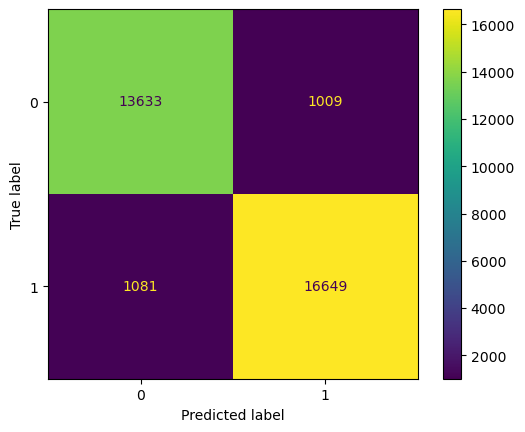

```python
# Creating and displaying a confusion matrix
cm = metrics.confusion_matrix(y_test, dt_pred, labels = decision_tree.classes_)
disp = metrics.ConfusionMatrixDisplay(confusion_matrix = cm,display_labels = decision_tree.classes_)
disp.plot()
```

**Observations**:

> - In the confusion matrix, there are a high proportion of true positives and true negatives (where the matrix accurately predicted that the customer would be satisfied or dissatified, respectively).
> - The matrix also had a relatively low number of false positives and false negatives (where the matrix innacurately predicted that the customer would be satisfied or dissatified, respectively.)

### Plotting the decision tree

> - I'll use the `plot_tree` function to produce a visual representation of the tree to pinpoint where the splits in the data are occurring.

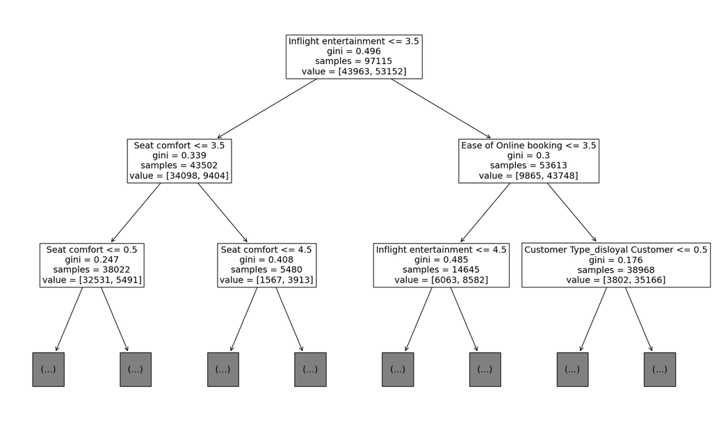

```python
plt.figure(figsize=(20,12))
plot_tree(decision_tree, max_depth=2, fontsize=14, feature_names=X.columns);
```

### Calculating feature importance

> - The `DecisionTreeClassifier` class comes with a [`feature_importances`](https://scikit-learn.org/stable/modules/generated/sklearn.tree.DecisionTreeClassifier.html#sklearn.tree.DecisionTreeClassifier.feature_importances_) attribute that provides access to the features' relative importance in the model. The feature importances are computed when the `fit()` method is called on the `DecisionTreeClassifier` instance.
> - By using the `feature_importances` attribute to fetch the relative importances of each feature, I can then plot the results.

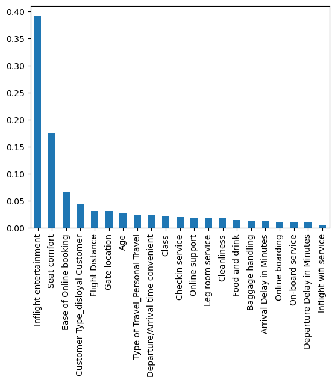

```python
importances = decision_tree.feature_importances_

forest_importances = pd.Series(importances, index=X.columns).sort_values(ascending=False)

fig, ax = plt.subplots()
forest_importances.plot.bar(ax=ax);
```

**Observations**:

> - The feature importance graph seems to confirm that `'Inflight entertainment'`, `'Seat comfort'`, and `'Ease of Online booking'` are the most important features for this model.

### Hyperparameter tuning

> - Knowing how and when to adjust or tune a model can help a data professional significantly increase performance. In this section, I will find the best values for the hyperparameters `max_depth` and `min_samples_leaf` using grid search and cross validation. Below are some values for the hyperparameters `max_depth` and `min_samples_leaf`.

```python
tree_para = {'max_depth':[1,2,3,4,5,6,7,8,9,10,11,12,13,14,15,16,17,18,19,20,30,40,50],
             'min_samples_leaf': [2,3,4,5,6,7,8,9, 10, 15, 20, 50]}

scoring = {'accuracy', 'precision', 'recall', 'f1'}
```

### Checking combinations of values

> - I'll now check every combination of values to examine which pair has the best evaluation metrics. Then I'll make a decision tree instance called `tuned_decision_tree` with `random_state=0`, make a `GridSearchCV` instance called `clf`, and make sure to refit the estimator using `"f1"`, and fit the model on the training set.
> - **Note:** This cell may take up to 5 minutes to run.

```python
# Checking every combination of values
tuned_decision_tree = DecisionTreeClassifier(random_state=0)

clf = GridSearchCV(tuned_decision_tree,
                   tree_para,
                   scoring = scoring,
                   cv=5,
                   refit="f1")

clf.fit(X_train, y_train)
```

```
GridSearchCV(cv=5, estimator=DecisionTreeClassifier(random_state=0),
             param_grid={'max_depth': [1, 2, 3, 4, 5, 6, 7, 8, 9, 10, 11, 12,
                                       13, 14, 15, 16, 17, 18, 19, 20, 30, 40,
                                       50],
                         'min_samples_leaf': [2, 3, 4, 5, 6, 7, 8, 9, 10, 15,
                                              20, 50]},
             refit='f1', scoring={'f1', 'accuracy', 'precision', 'recall'})
```

**Observation**:

> - I now use the best estimator tool to help uncover the best pair combination.

```python
# Computing the best combination of values for the hyperparameters
clf.best_estimator_
```

```
DecisionTreeClassifier(max_depth=18, min_samples_leaf=2, random_state=0)
```

**Observations**:

> - After running the DecisionTreeClassifier, the maximum depth is `18` and the minimum number of samples is `2`, meaning this is the best combination of values.

### Determining the best average validation score

```python
print("Best Avg. Validation Score: ", "%.4f" % clf.best_score_)
```

```
Best Avg. Validation Score:  0.9454
```

**Observation**:

> - The best validation score is: `0.9454`.

```python
# Printing out the decision tree model's accuracy, precision, recall, and F1 score.
results = pd.DataFrame(columns=['Model', 'F1', 'Recall', 'Precision', 'Accuracy'])

def make_results(model_name, model_object):
    """
    Accepts as arguments a model name (your choice - string) and
    a fit GridSearchCV model object.

    Returns a pandas df with the F1, recall, precision, and accuracy scores
    for the model with the best mean F1 score across all validation folds.
    """

    # Getting all the results from the CV and putting them in a df.
    cv_results = pd.DataFrame(model_object.cv_results_)

    # Isolating the row of the df with the max(mean f1 score).
    best_estimator_results = cv_results.iloc[cv_results['mean_test_f1'].idxmax(), :]

    # Extracting accuracy, precision, recall, and f1 score from that row.
    f1 = best_estimator_results.mean_test_f1
    recall = best_estimator_results.mean_test_recall
    precision = best_estimator_results.mean_test_precision
    accuracy = best_estimator_results.mean_test_accuracy


    # Creating a table of results
    table = pd.DataFrame({'Model': [model_name],
                          'F1': [f1],
                          'Recall': [recall],
                          'Precision': [precision],
                          'Accuracy': [accuracy]
                         }
                        )

    return table

result_table = make_results("Tuned Decision Tree", clf)

result_table
```

|  | Model | F1 | Recall | Precision | Accuracy |
| --- | --- | --- | --- | --- | --- |
| 0 | Tuned Decision Tree | 0.945422 | 0.935863 | 0.955197 | 0.940864 |

**Observations**:

> - The F1 score for the decision tree that was not hyperparameter tuned is `0.940940` and the F1 score for the hyperparameter-tuned decision tree is `0.945422`. While ensuring that overfitting doesn't occur is necessary for some models, it didn't make a meaningful difference in improving this model.

### Plotting the "best" decision tree

> - I'll now use the `plot_tree` function to produce a representation of the tree to pinpoint where the splits in the data are occurring. This will allow me to review the "best" decision tree.

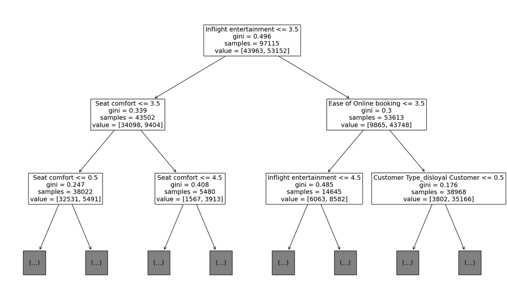

```python
plt.figure(figsize=(20,12))
plot_tree(clf.best_estimator_, max_depth=2, fontsize=14, feature_names=X.columns);
```

**Observations**:

> - The plot makes it seem like `'Inflight entertainment'`, `'Seat comfort'`, and `'Ease of Online booking'` are among the most important features.

### Building another feature importance graph

> - I'll build another feature importance graph to validate which features are most important.

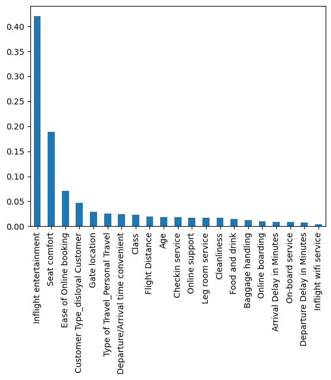

```python
importances = clf.best_estimator_.feature_importances_

forest_importances = pd.Series(importances, index=X.columns).sort_values(ascending=False)

fig, ax = plt.subplots()
forest_importances.plot.bar(ax=ax);
```

**Observations**:

> - The feature importance graph seems to confirm that `'Inflight entertainment'`, `'Seat comfort'`, and `'Ease of Online booking'` are the "most important" features for this model.

Any of the metrics in this business case could be considered important, depending on what the stakeholder or domain expert cares about. The following are reasons why each metric is important:

> - **`Accuracy`** tends to be the metric that the stakeholders can best understand.
> - **`Precision`** measures what proportion of predicted positives is truly positive. For example, if I wanted to not falsely claim a customer is satisfied, precision would be a good metric. Assuming a customer is happy when they are really not might lead to customer churn.
> - **`Recall`** measures the percentage of actual positives a model correctly identified (true positive). For this dataset, the airline might want to limit false negatives (actually satisfied people who are predicted to be unsatisfied). Assuming a customer is unhappy when the customer is happy can lead to the airline wasting resources trying to improve the customer experience of an already happy customer.
> - **`F1`** balances precision and recall. It is the harmonic mean of precision and recall, or their product divided by their sum.

# Considerations

**Takeaways**:

- Machine learning workflows may be used to clean and encode data for machine learning.
- While hyperparameter tuning can lead to an increase in performance, it doesn't always.
- The visualization of the decision tree as well as the feature graph can be used to determine which features are most important for a decision tree.

**Findings to share with others**:

- Decision trees accurately predicted satisfaction over 94 percent of the time.
- The confusion matrix is useful as it shows a similar number of true positives and true negatives.
- The visualization of the decision tree and the feature importance graph both suggest that `Inflight entertainment`, `Seat comfort`, and `Ease of Online booking` are the most important features in the model.

**Recommendations to stakeholders**:

- Customer satisfaction is highly tied to 'Inflight entertainment', 'Seat comfort', and 'Ease of Online booking'. Improving these experiences should lead to better customer satisfaction.
- The success of the model suggests that the airline should invest more effort into model building and model understanding since this model semed to be very good at predicting customer satisfaction.